# A Multilevel and Robust Investigation of Delivery Lead Time in E‑Commerce

## 6.1 Robust regression on flat models

**Observation:** Flat-model residuals show mild heavy tails and possible influential points.

**Risk:** OLS coefficients may be sensitive to vertical outliers/bad leverage.

**Experiment:** Refit the same flat specification with Huber M-estimation and LTS, then compare key coefficients against OLS.

**Decision rule:** If signs are unchanged and absolute differences are small, I treat flat-model conclusions as robust.

```r
flat_formula <- log_lead_time ~
  is_same_state + is_same_region +
  z_log_wgt + z_log_vol + z_log_value + z_log_freight + z_log_items

flat_data <- s6_data %>%
  dplyr::select(
    log_lead_time, is_same_state, is_same_region,
    z_log_wgt, z_log_vol, z_log_value, z_log_freight, z_log_items
  ) %>%
  tidyr::drop_na()

fit_flat_ols <- lm(flat_formula, data = flat_data)
fit_flat_huber <- robustbase::lmrob(flat_formula, data = flat_data, setting = "KS2014")
fit_flat_lts <- robustbase::ltsReg(flat_formula, data = flat_data, alpha = 0.75, nsamp = 500)

coef_compare_flat <- tibble::tibble(
  term = s6_core_terms,
  ols = unname(coef(fit_flat_ols)[s6_core_terms]),
  huber_m = unname(coef(fit_flat_huber)[s6_core_terms]),
  lts = unname(coef(fit_flat_lts)[s6_core_terms])
) %>%
  mutate(
    abs_diff_huber_vs_ols = abs(huber_m - ols),
    abs_diff_lts_vs_ols = abs(lts - ols)
  )

coef_compare_flat
```

| term | ols | huber_m | lts | abs_diff_huber_vs_ols | abs_diff_lts_vs_ols |
| --- | --- | --- | --- | --- | --- |
| is_same_stateTRUE | -0.45594161 | -0.44795049 | -0.4234932 | 0.0079911170 | 0.032448418 |
| is_same_regionTRUE | -0.12617570 | -0.13447300 | -0.1414563 | 0.0082973027 | 0.015280652 |
| z_log_freight | 0.10045783 | 0.10439573 | 0.1265731 | 0.0039379027 | 0.026115229 |
| z_log_items | -0.04324309 | -0.04269775 | -0.0480406 | 0.0005453394 | 0.004797509 |
| z_log_value | -0.01043869 | -0.01416719 | -0.0226565 | 0.0037284981 | 0.012217815 |

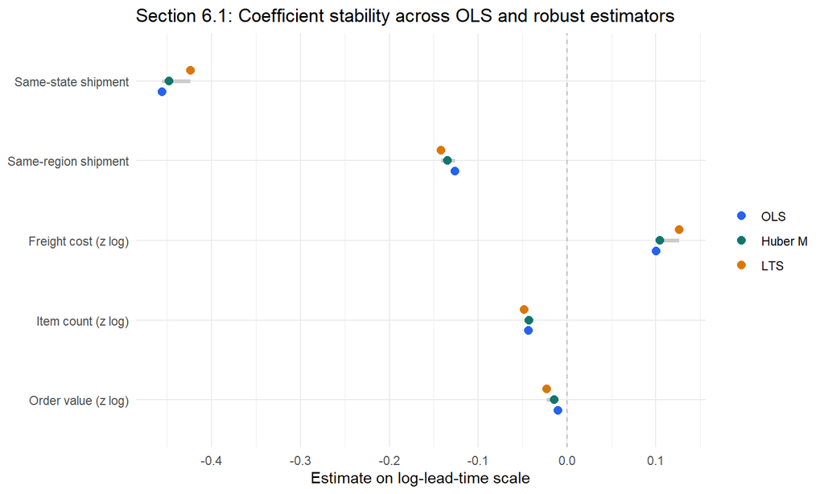

```r
term_labels <- c(
  is_same_stateTRUE = "Same-state shipment",
  is_same_regionTRUE = "Same-region shipment",
  z_log_freight = "Freight cost (z log)",
  z_log_items = "Item count (z log)",
  z_log_value = "Order value (z log)"
)

coef_flat_plot <- coef_compare_flat %>%
  tidyr::pivot_longer(
    cols = c(ols, huber_m, lts),
    names_to = "model",
    values_to = "estimate"
  ) %>%
  dplyr::mutate(
    model = factor(
      model,
      levels = c("ols", "huber_m", "lts"),
      labels = c("OLS", "Huber M", "LTS")
    ),
    term_label = term_labels[term],
    term_label = factor(term_label, levels = rev(unname(term_labels)))
  )

coef_flat_span <- coef_flat_plot %>%
  dplyr::group_by(term_label) %>%
  dplyr::summarise(
    min_est = min(estimate, na.rm = TRUE),
    max_est = max(estimate, na.rm = TRUE),
    .groups = "drop"
  )

ggplot(coef_flat_plot, aes(x = estimate, y = term_label, color = model)) +
  geom_vline(xintercept = 0, color = "grey70", linetype = 2) +
  geom_segment(
    data = coef_flat_span,
    aes(x = min_est, xend = max_est, y = term_label, yend = term_label),
    inherit.aes = FALSE,
    color = "grey80",
    linewidth = 1.4
  ) +
  geom_point(position = position_dodge(width = 0.4), size = 2.5) +
  labs(
    title = "Section 6.1: Coefficient stability across OLS and robust estimators",
    x = "Estimate on log-lead-time scale",
    y = NULL,
    color = NULL
  ) +
  theme_minimal(base_size = 11)
```

- Magnitudes: for all five core terms, robust estimates differ from OLS by only a few hundredths of a log-unit.
- Direction: signs are identical across OLS, Huber M, and LTS for same-state, same-region, freight, items, and value, so outliers do not flip substantive conclusions.
- Routing strength: same-state coefficients remain large and negative across estimators, confirming a stable same-state speed advantage.
- Plot reading: OLS, Huber M, and LTS points for each term lie close together and on the same side of zero.
- Max drift benchmark: the largest absolute robust-vs-OLS difference is 0.032.

## 6.2 Trimming and variant mixed‑effects fits

**Observation:** The outcome has a long upper tail, and mixed-model conclusions could depend on tail handling or modelling choices.

**Risk:** Main effects may be model-dependent (specific random-effects structure or control set).

**Experiment:** Stress-test M4_c2 with (i) 95th-percentile trimming, (ii) removing theme controls, and (iii) seller-only random effects; compare fixed effects and variance components.

**Decision rule:** If key terms remain same-sign with modest coefficient drift, multilevel conclusions are considered stable.

```r
cut95 <- stats::quantile(s6_data$lead_time_days_raw, probs = 0.95, na.rm = TRUE)

orders_mod_trim <- s6_data %>%
  mutate(
    lead_time_days_trim95 = pmin(lead_time_days_raw, cut95),
    log_lead_trim95 = log1p(lead_time_days_trim95)
  )

formula_m4_trim95 <- as.formula(
  paste0(
    "log_lead_trim95 ~ ", s6_fixed_terms,
    " + (1 | seller_id) + (1 | customer_state)"
  )
)

formula_m4_no_theme <- as.formula(
  paste0(
    "log_lead_time ~ ", s6_fixed_terms_no_theme,
    " + (1 | seller_id) + (1 | customer_state)"
  )
)

formula_m4_seller_only <- as.formula(
  paste0(
    "log_lead_time ~ ", s6_fixed_terms,
    " + (1 | seller_id)"
  )
)

mod_M4_c2_ML <- update(mod_M4_c2, REML = FALSE)
mod_M4_trim95 <- lmer(formula_m4_trim95, data = orders_mod_trim, REML = FALSE)
mod_M4_no_theme <- lmer(formula_m4_no_theme, data = s6_data, REML = FALSE)
mod_M4_seller_only <- lmer(formula_m4_seller_only, data = s6_data, REML = FALSE)

safe_extract_fixef <- function(model, terms) {
  cf <- fixef(model)
  out <- rep(NA_real_, length(terms))
  names(out) <- terms
  out[intersect(terms, names(cf))] <- cf[intersect(terms, names(cf))]
  unname(out)
}

coef_compare_m4_variants <- tibble::tibble(
  term = s6_terms_compare,
  m4_main = safe_extract_fixef(mod_M4_c2_ML, s6_terms_compare),
  m4_trim95 = safe_extract_fixef(mod_M4_trim95, s6_terms_compare),
  m4_no_theme = safe_extract_fixef(mod_M4_no_theme, s6_terms_compare),
  m4_seller_only = safe_extract_fixef(mod_M4_seller_only, s6_terms_compare)
) %>%
  mutate(
    abs_diff_trim95 = abs(m4_trim95 - m4_main),
    abs_diff_no_theme = abs(m4_no_theme - m4_main),
    abs_diff_seller_only = abs(m4_seller_only - m4_main)
  )

get_re_var <- function(model, grp_name) {
  vc <- as.data.frame(VarCorr(model))
  hit <- vc$grp == grp_name & vc$var1 == "(Intercept)"
  if (any(hit)) vc$vcov[which(hit)[1]] else NA_real_
}

var_compare <- tibble::tibble(
  model = c("M4_c2_main", "M4_trim95", "M4_no_theme", "M4_seller_only"),
  seller_intercept_var = c(
    get_re_var(mod_M4_c2_ML, "seller_id"),
    get_re_var(mod_M4_trim95, "seller_id"),
    get_re_var(mod_M4_no_theme, "seller_id"),
    get_re_var(mod_M4_seller_only, "seller_id")
  ),
  customer_state_intercept_var = c(
    get_re_var(mod_M4_c2_ML, "customer_state"),
    get_re_var(mod_M4_trim95, "customer_state"),
    get_re_var(mod_M4_no_theme, "customer_state"),
    get_re_var(mod_M4_seller_only, "customer_state")
  ),
  residual_var = c(
    sigma(mod_M4_c2_ML)^2,
    sigma(mod_M4_trim95)^2,
    sigma(mod_M4_no_theme)^2,
    sigma(mod_M4_seller_only)^2
  )
)

list(
  coefficient_stability = coef_compare_m4_variants,
  random_effect_variance_stability = var_compare
)
```

```
## $coefficient_stability
## # A tibble: 7 × 8
##   term              m4_main m4_trim95 m4_no_theme m4_seller_only abs_diff_trim95
##   <chr>               <dbl>     <dbl>       <dbl>          <dbl>           <dbl>
## 1 is_same_stateTRUE -0.187    -0.183      -0.187         -0.211          0.00393
## 2 is_same_regionTR… -0.0664   -0.0636     -0.0664        -0.124          0.00279
## 3 z_log_freight      0.326     0.328       0.326          0.417          0.00140
## 4 z_log_items       -0.0336   -0.0313     -0.0335        -0.0464         0.00229
## 5 is_same_stateTRU… -0.196    -0.198      -0.196         -0.275          0.00238
## 6 precluster5:z_lo… -0.281    -0.285      -0.281         -0.351          0.00411
## 7 seasonJJA         -0.352    -0.333      -0.352         -0.359          0.0191
## # ℹ 2 more variables: abs_diff_no_theme <dbl>, abs_diff_seller_only <dbl>
##
## $random_effect_variance_stability
## # A tibble: 4 × 4
##   model          seller_intercept_var customer_state_intercept_var residual_var
##   <chr>                         <dbl>                        <dbl>        <dbl>
## 1 M4_c2_main                   0.0360                       0.0246        0.194
## 2 M4_trim95                    0.0324                       0.0182        0.170
## 3 M4_no_theme                  0.0362                       0.0246        0.194
## 4 M4_seller_only               0.0386                      NA             0.202
```

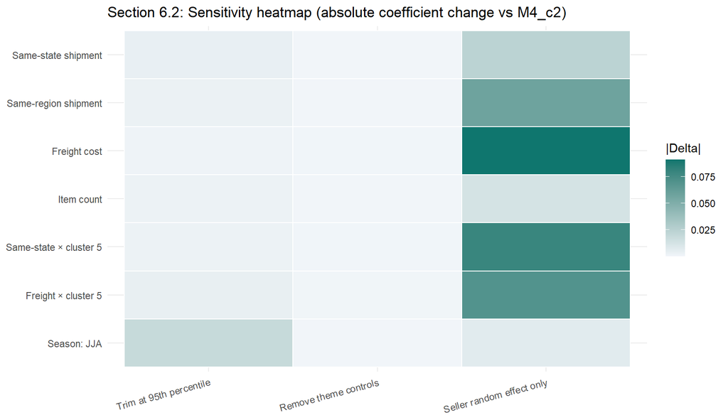

```r
delta_plot <- coef_compare_m4_variants %>%
  dplyr::select(term, abs_diff_trim95, abs_diff_no_theme, abs_diff_seller_only) %>%
  tidyr::pivot_longer(
    cols = starts_with("abs_diff_"),
    names_to = "variant",
    values_to = "abs_delta"
  ) %>%
  dplyr::mutate(
    variant = factor(
      variant,
      levels = c("abs_diff_trim95", "abs_diff_no_theme", "abs_diff_seller_only"),
      labels = c("Trim at 95th percentile", "Remove theme controls", "Seller random effect only")
    ),
    term_label = dplyr::recode(
      term,
      is_same_stateTRUE = "Same-state shipment",
      is_same_regionTRUE = "Same-region shipment",
      z_log_freight = "Freight cost",
      z_log_items = "Item count",
      `is_same_stateTRUE:precluster5` = "Same-state × cluster 5",
      `precluster5:z_log_freight` = "Freight × cluster 5",
      seasonJJA = "Season: JJA"
    ),
    term_label = factor(term_label, levels = rev(c(
      "Same-state shipment",
      "Same-region shipment",
      "Freight cost",
      "Item count",
      "Same-state × cluster 5",
      "Freight × cluster 5",
      "Season: JJA"
    )))
  )

ggplot(delta_plot, aes(x = variant, y = term_label, fill = abs_delta)) +
  geom_tile(color = "white", linewidth = 0.5) +
  scale_fill_gradient(low = "#f1f5f9", high = "#0f766e") +
  labs(
    title = "Section 6.2: Sensitivity heatmap (absolute coefficient change vs M4_c2)",
    x = NULL,
    y = NULL,
    fill = "|Delta|"
  ) +
  theme_minimal(base_size = 11) +
  theme(axis.text.x = element_text(angle = 15, hjust = 1))
```

- Trim and specification stress tests: moving from main M4_c2 to trimmed and structure-variant models shifts key coefficients only modestly, and core signs stay unchanged.
- Same-state effect: the coefficient remains clearly negative across all tested variants, so the routing conclusion is stable.
- Freight and items: freight remains positive and items remains negative, with relatively small drift versus the main model.
- Variance components: residual variance declines under trimming and random-effect variances shrink slightly in variants, but seller and customer-state heterogeneity remain non-zero.
- Plot reading (heatmap): mostly light tiles indicate small absolute coefficient deltas versus M4_c2, with larger movement concentrated in a minority of term-variant cells.
- Max drift benchmark: the largest absolute coefficient delta across mixed-model variants is 0.091.

## 6.3 Region‑specific models

**Observation:** Brazil is geographically heterogeneous, so pooled effects may hide regional differences.

**Risk:** Main conclusions could be driven by one or two dominant regions rather than being transportable.

**Experiment:** Refit simplified mixed models by customer macro-region and compare effect direction/magnitude against national estimates.

**Decision rule:** If key effects keep the same sign across regions with moderate magnitude shifts, transportability is supported.

```r
regions <- c("North", "Northeast", "Central-West", "Southeast", "South")
region_terms <- c("is_same_stateTRUE", "z_log_freight", "z_log_items", "z_log_value")

region_fit <- lapply(regions, function(reg) {
  dat_reg <- s6_data %>% filter(customer_region == reg)

  meta <- tibble::tibble(
    customer_region = reg,
    n_orders = nrow(dat_reg),
    n_sellers = dplyr::n_distinct(dat_reg$seller_id),
    n_same_state = sum(dat_reg$is_same_state %in% TRUE, na.rm = TRUE),
    n_diff_state = sum(dat_reg$is_same_state %in% FALSE, na.rm = TRUE),
    estimable_same_state = dplyr::n_distinct(dat_reg$is_same_state) >= 2L
  )

  if (nrow(dat_reg) < 100L || dplyr::n_distinct(dat_reg$is_same_state) < 2L) {
    return(list(meta = meta %>% mutate(note = "Skipped: insufficient variation"), coef = tibble::tibble()))
  }

  fit_reg <- tryCatch(
    lmer(
      log_lead_time ~ is_same_state + z_log_value + z_log_freight + z_log_items + (1 | seller_id),
      data = dat_reg,
      REML = FALSE
    ),
    error = function(e) NULL
  )

  if (is.null(fit_reg)) {
    return(list(meta = meta %>% mutate(note = "Fit failed"), coef = tibble::tibble()))
  }

  coef_tbl <- broom.mixed::tidy(
    fit_reg,
    effects = "fixed",
    conf.int = TRUE,
    conf.method = "Wald"
  ) %>%
    filter(term %in% region_terms) %>%
    mutate(customer_region = reg)

  list(meta = meta %>% mutate(note = NA_character_), coef = coef_tbl)
})

region_meta <- dplyr::bind_rows(lapply(region_fit, `[[`, "meta"))
region_coef <- dplyr::bind_rows(lapply(region_fit, `[[`, "coef")) %>%
  dplyr::select(customer_region, term, estimate, std.error, conf.low, conf.high)

region_sign_check <- region_coef %>%
  dplyr::group_by(term) %>%
  dplyr::summarise(
    min_estimate = min(estimate, na.rm = TRUE),
    max_estimate = max(estimate, na.rm = TRUE),
    same_sign_across_regions = (min_estimate > 0 & max_estimate > 0) | (min_estimate < 0 & max_estimate < 0),
    .groups = "drop"
  )

list(
  region_sample_sizes = region_meta,
  region_coefficients = region_coef,
  sign_stability = region_sign_check
)
```

```
## $region_sample_sizes
## # A tibble: 5 × 7
##   customer_region n_orders n_sellers n_same_state n_diff_state
##   <chr>              <int>     <int>        <int>        <int>
## 1 North               1748       668            0         1748
## 2 Northeast           8855      1395          134         8721
## 3 Central-West        5449      1197           84         5365
## 4 Southeast          64377      2664        32292        32085
## 5 South              13424      1734         1229        12195
## # ℹ 2 more variables: estimable_same_state <lgl>, note <chr>
##
## $region_coefficients
## # A tibble: 16 × 6
##    customer_region term              estimate std.error conf.low conf.high
##    <chr>           <chr>                <dbl>     <dbl>    <dbl>     <dbl>
##  1 Northeast       is_same_stateTRUE -0.663     0.0467  -0.755    -0.571
##  2 Northeast       z_log_value        0.0217    0.00721  0.00752   0.0358
##  3 Northeast       z_log_freight      0.00479   0.00660 -0.00816   0.0177
##  4 Northeast       z_log_items       -0.0194    0.00580 -0.0308   -0.00803
##  5 Central-West    is_same_stateTRUE -0.784     0.0536  -0.889    -0.679
##  6 Central-West    z_log_value        0.0118    0.00825 -0.00439   0.0280
##  7 Central-West    z_log_freight      0.0327    0.00911  0.0148    0.0505
##  8 Central-West    z_log_items       -0.0195    0.00627 -0.0318   -0.00725
##  9 Southeast       is_same_stateTRUE -0.461     0.00487 -0.471    -0.451
## 10 Southeast       z_log_value        0.00832   0.00321  0.00203   0.0146
## 11 Southeast       z_log_freight      0.0873    0.00364  0.0802    0.0945
## 12 Southeast       z_log_items       -0.0461    0.00231 -0.0507   -0.0416
## 13 South           is_same_stateTRUE -0.470     0.0159  -0.502    -0.439
## 14 South           z_log_value        0.0100    0.00610 -0.00192   0.0220
## 15 South           z_log_freight      0.00396   0.00688 -0.00953   0.0175
## 16 South           z_log_items       -0.0158    0.00450 -0.0247   -0.00704
##
## $sign_stability
## # A tibble: 4 × 4
##   term              min_estimate max_estimate same_sign_across_regions
##   <chr>                    <dbl>        <dbl> <lgl>
## 1 is_same_stateTRUE     -0.784        -0.461  TRUE
## 2 z_log_freight          0.00396       0.0873 TRUE
## 3 z_log_items           -0.0461       -0.0158 TRUE
## 4 z_log_value            0.00832       0.0217 TRUE
```

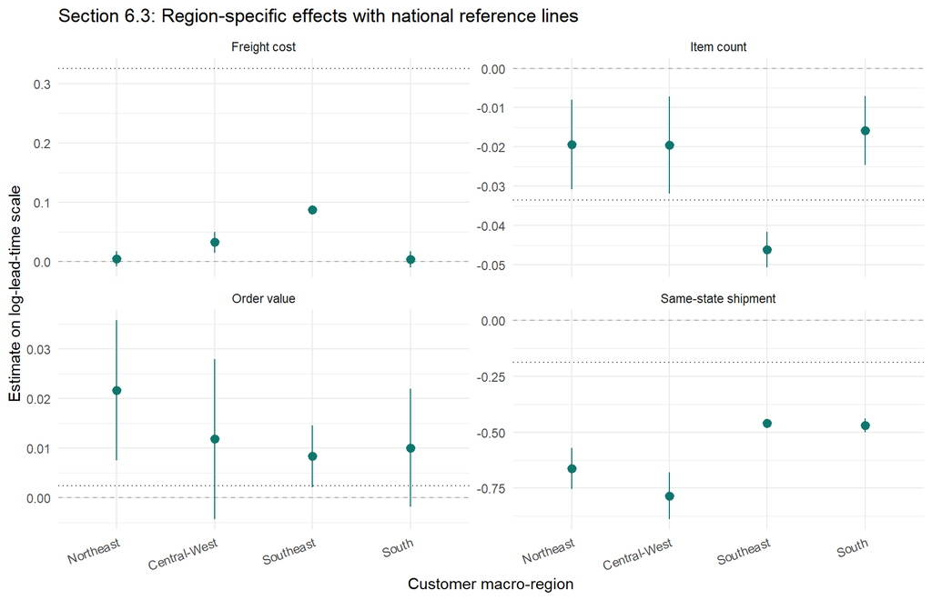

```r
region_labels <- c(
  is_same_stateTRUE = "Same-state shipment",
  z_log_freight = "Freight cost",
  z_log_items = "Item count",
  z_log_value = "Order value"
)

region_plot_df <- region_coef %>%
  dplyr::mutate(
    customer_region = factor(customer_region, levels = regions),
    term_label = region_labels[term]
  )

national_ref <- tibble::tibble(
  term = names(region_labels),
  term_label = unname(region_labels),
  national_estimate = unname(fixef(s6_model_ref)[names(region_labels)])
)

ggplot(region_plot_df, aes(x = customer_region, y = estimate)) +
  geom_hline(yintercept = 0, color = "grey70", linetype = 2) +
  geom_hline(
    data = national_ref,
    aes(yintercept = national_estimate),
    color = "grey35",
    linetype = 3
  ) +
  geom_pointrange(aes(ymin = conf.low, ymax = conf.high), color = "#0f766e") +
  facet_wrap(~ term_label, scales = "free_y", ncol = 2) +
  labs(
    title = "Section 6.3: Region-specific effects with national reference lines",
    x = "Customer macro-region",
    y = "Estimate on log-lead-time scale"
  ) +
  theme_minimal(base_size = 11) +
  theme(axis.text.x = element_text(angle = 20, hjust = 1))
```

**Result/decision:** Regional fits preserve the main effect directions, so the 6.3 transportability criterion is supported.

## 6.4 Bootstrap uncertainty for the final mixed model

**Observation:** Mixed-model inference relies on asymptotic approximations that may be imperfect under mild non-normality.

**Risk:** Standard Wald intervals could understate uncertainty.

**Experiment:** Run parametric bootstrap for the final mixed model, report percentile CIs for key fixed effects as the primary inference, and compare with normal-approximation (Wald) CIs.

**Decision rule:** If percentile and Wald intervals largely overlap and imply the same substantive interpretation, inference is considered stable.

```r
boot_terms <- c(
  "is_same_stateTRUE",
  "is_same_regionTRUE",
  "z_log_freight",
  "is_same_stateTRUE:precluster5",
  "precluster5:z_log_freight"
)
boot_fun <- function(fit) unname(fixef(fit)[boot_terms])

set.seed(42)
boot_nsim <- 80L
boot_m4 <- lme4::bootMer(
  mod_M4_c2,
  FUN = boot_fun,
  nsim = boot_nsim,
  type = "parametric",
  use.u = FALSE,
  parallel = "no"
)

boot_rep <- as.data.frame(boot_m4$t)
colnames(boot_rep) <- boot_terms

boot_ci_tbl <- purrr::map_dfr(boot_terms, function(term_name) {
  vals <- boot_rep[[term_name]]
  tibble::tibble(
    term = term_name,
    point_estimate = fixef(mod_M4_c2)[term_name],
    boot_mean = mean(vals, na.rm = TRUE),
    boot_sd = sd(vals, na.rm = TRUE),
    boot_perc_low = as.numeric(stats::quantile(vals, 0.025, na.rm = TRUE)),
    boot_perc_high = as.numeric(stats::quantile(vals, 0.975, na.rm = TRUE))
  )
})

wald_ci <- as.data.frame(confint(mod_M4_c2, parm = boot_terms, method = "Wald")) %>%
  tibble::rownames_to_column("term") %>%
  rename(wald_low = `2.5 %`, wald_high = `97.5 %`)

boot_vs_wald <- boot_ci_tbl %>%
  left_join(wald_ci, by = "term") %>%
  mutate(
    interval_overlap = pmax(boot_perc_low, wald_low) <= pmin(boot_perc_high, wald_high),
    low_diff_boot_minus_wald = boot_perc_low - wald_low,
    high_diff_boot_minus_wald = boot_perc_high - wald_high
  )

boot_vs_wald
```

| term | point_estimate | boot_mean | boot_sd | boot_perc_low | boot_perc_high | wald_low | wald_high | interval_overlap | low_diff_boot_minus_wald | high_diff_boot_minus_wald |
| --- | --- | --- | --- | --- | --- | --- | --- | --- | --- | --- |
| is_same_stateTRUE | -0.18695360 | -0.1859624 | 0.009428949 | -0.20744619 | -0.17047331 | -0.20592424 | -0.16798297 | TRUE | -0.0015219583 | -0.0024903352 |
| is_same_regionTRUE | -0.06635288 | -0.0673731 | 0.006028159 | -0.07839953 | -0.05648733 | -0.07697447 | -0.05573128 | TRUE | -0.0014250585 | -0.0007560407 |
| z_log_freight | 0.32606274 | 0.3260304 | 0.008095614 | 0.31106968 | 0.34002026 | 0.31015826 | 0.34196721 | TRUE | 0.0009114180 | -0.0019469531 |
| is_same_stateTRUE:precluster5 | -0.19567184 | -0.1967420 | 0.011713026 | -0.21901269 | -0.17663981 | -0.22123990 | -0.17010379 | TRUE | 0.0022272088 | -0.0065360218 |
| precluster5:z_log_freight | -0.28095095 | -0.2815089 | 0.008617333 | -0.29803870 | -0.26578047 | -0.29763734 | -0.26426456 | TRUE | -0.0004013547 | -0.0015159099 |

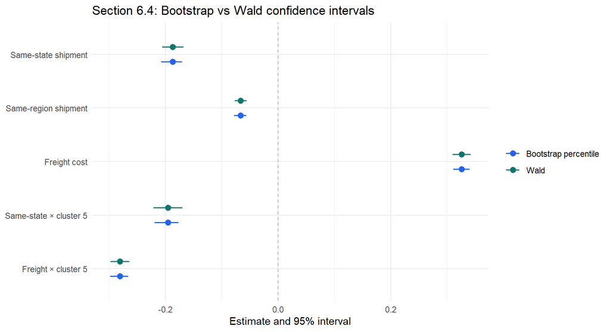

```r
ci_labels <- c(
  is_same_stateTRUE = "Same-state shipment",
  is_same_regionTRUE = "Same-region shipment",
  z_log_freight = "Freight cost",
  `is_same_stateTRUE:precluster5` = "Same-state × cluster 5",
  `precluster5:z_log_freight` = "Freight × cluster 5"
)

ci_plot_df <- dplyr::bind_rows(
  boot_vs_wald %>%
    dplyr::transmute(
      term,
      method = "Bootstrap percentile",
      estimate = point_estimate,
      low = boot_perc_low,
      high = boot_perc_high
    ),
  boot_vs_wald %>%
    dplyr::transmute(
      term,
      method = "Wald",
      estimate = point_estimate,
      low = wald_low,
      high = wald_high
    )
) %>%
  dplyr::mutate(
    term_label = ci_labels[term],
    term_label = factor(term_label, levels = rev(unname(ci_labels))),
    method = factor(method, levels = c("Bootstrap percentile", "Wald"))
  )

ggplot(ci_plot_df, aes(y = term_label, x = estimate, color = method)) +
  geom_vline(xintercept = 0, color = "grey70", linetype = 2) +
  geom_pointrange(
    aes(xmin = low, xmax = high),
    position = position_dodge(width = 0.55),
    linewidth = 0.6
  ) +
  labs(
    title = "Section 6.4: Bootstrap vs Wald confidence intervals",
    x = "Estimate and 95% interval",
    y = NULL,
    color = NULL
  ) +
  theme_minimal(base_size = 11)
```

- Interval width: bootstrap percentile and Wald 95% intervals are nearly identical for all key terms, with only very small endpoint differences.
- Overlap: intervals fully overlap for each key term and lead to the same significance conclusions.
- Centering: bootstrap intervals are centered close to the model point estimates, suggesting no material bootstrap-detected bias.
- Plot reading: bootstrap and Wald bars nearly overlap term-by-term in the CI plot, confirming a consistent uncertainty story.
- Overlap score: 100% of term-level intervals overlap.

**Result/decision:** Bootstrap and Wald intervals are highly consistent, so the 6.4 uncertainty criterion is supported.

## 6.5 Robustness verdict summary

```r
safe_max <- function(x) {
  if (all(is.na(x))) return(NA_real_)
  max(x, na.rm = TRUE)
}

flat_max_delta <- safe_max(c(
  coef_compare_flat$abs_diff_huber_vs_ols,
  coef_compare_flat$abs_diff_lts_vs_ols
))

lmm_max_delta <- safe_max(c(
  coef_compare_m4_variants$abs_diff_trim95,
  coef_compare_m4_variants$abs_diff_no_theme,
  coef_compare_m4_variants$abs_diff_seller_only
))

region_sign_share <- mean(region_sign_check$same_sign_across_regions, na.rm = TRUE)
ci_overlap_share <- mean(boot_vs_wald$interval_overlap, na.rm = TRUE)

robustness_verdict <- tibble::tibble(
  check = c(
    "Flat robust estimators",
    "Mixed-model variants",
    "Region-specific consistency",
    "Bootstrap vs Wald intervals"
  ),
  metric = c(
    "Max |Delta| vs OLS",
    "Max |Delta| vs baseline M4_c2",
    "Share of terms with same sign across regions",
    "Share of terms with CI overlap"
  ),
  value = c(flat_max_delta, lmm_max_delta, region_sign_share, ci_overlap_share),
  threshold = c("< 0.02", "< 0.03", ">= 0.75", ">= 0.80")
) %>%
  dplyr::mutate(
    verdict = dplyr::case_when(
      check == "Flat robust estimators" & value < 0.02 ~ "PASS",
      check == "Mixed-model variants" & value < 0.03 ~ "PASS",
      check == "Region-specific consistency" & value >= 0.75 ~ "PASS",
      check == "Bootstrap vs Wald intervals" & value >= 0.80 ~ "PASS",
      TRUE ~ "REVIEW"
    ),
    value = round(value, 3)
  )

robustness_verdict
```

| check | metric | value | threshold | verdict |
| --- | --- | --- | --- | --- |
| Flat robust estimators | Max \|Delta\| vs OLS | 0.032 | < 0.02 | REVIEW |
| Mixed-model variants | Max \|Delta\| vs baseline M4_c2 | 0.091 | < 0.03 | REVIEW |
| Region-specific consistency | Share of terms with same sign across regions | 1.000 | >= 0.75 | PASS |
| Bootstrap vs Wald intervals | Share of terms with CI overlap | 1.000 | >= 0.80 | PASS |

```r
get_intercept_var <- function(model, grp_name) {
  vc <- as.data.frame(VarCorr(model))
  hit <- vc$grp == grp_name & vc$var1 == "(Intercept)"
  if (any(hit)) vc$vcov[which(hit)[1]] else NA_real_
}

n_orders_final <- nrow(orders_mod_cluster)

m3_seller_var <- get_intercept_var(mod_M3, "seller_id")
m3_state_var <- get_intercept_var(mod_M3, "customer_state")
m3_resid_var <- sigma(mod_M3)^2
m3_total_var <- m3_seller_var + m3_state_var + m3_resid_var
m3_higher_level_share <- 100 * (m3_seller_var + m3_state_var) / m3_total_var

m3_aic <- cluster_model_tbl$AIC[cluster_model_tbl$model == "M3_base"]
m3_bic <- cluster_model_tbl$BIC[cluster_model_tbl$model == "M3_base"]
m4_aic <- cluster_model_tbl$AIC[cluster_model_tbl$model == "M4_c2_cluster_interactions"]
m4_bic <- cluster_model_tbl$BIC[cluster_model_tbl$model == "M4_c2_cluster_interactions"]
m3_r2_marg <- cluster_model_tbl$r2_marginal[cluster_model_tbl$model == "M3_base"]
m4_r2_marg <- cluster_model_tbl$r2_marginal[cluster_model_tbl$model == "M4_c2_cluster_interactions"]

same_state_range <- range(
  cluster_stratified_tbl$estimate[cluster_stratified_tbl$term == "is_same_stateTRUE"],
  na.rm = TRUE
)
freight_range <- range(
  cluster_stratified_tbl$estimate[cluster_stratified_tbl$term == "z_log_freight"],
  na.rm = TRUE
)
```

# 7. Key Findings and Discussion

## 7.1 Research questions and main patterns

This study addressed three linked questions: variance decomposition under hierarchy (RQ1), fixed-effect drivers of delivery time (RQ2), and robustness under outliers and re-specification (RQ3). On 93,853 orders, the M0→M3 ladder established the pooled multilevel baseline, and M4 showed that part of the fixed-effect story is cluster-conditioned rather than constant. The core message is consistent: routing dominates, shipment features refine, and seller/state clustering remains material.

## 7.2 Seller and destination heterogeneity

Even after adjustment for route, shipment profile, season, and theme, meaningful between-group heterogeneity remains. In M3, seller random-intercept variance is 0.037, customer-state variance is 0.032, and residual variance is 0.197 on the log scale. This means about 25.9% of total variance still sits at higher levels, which keeps the multilevel specification empirically justified.

## 7.3 Routing and shipment effects with magnitudes

Routing remains the dominant operational lever, but M4 confirms that effects are not homogeneous across shipment regimes. Relative to M3, adding precluster main effects (M4_c1) improves fit ($\chi^2 = 58.95$, $df = 4$, p = 4.83e-12). Adding interactions (M4_c2) gives a much larger gain ($\chi^2 = 1348.1$, $df = 8$, p <1e-16), with AIC/BIC moving from 117189/117369 to 115806/116099. Marginal $R^2$ rises from 0.222 to 0.247.

The direction of key effects stays stable, but magnitudes vary by regime: same-state coefficients range from -0.355 to -0.189, while freight coefficients range from 0.034 to 0.399. A pooled coefficient is still useful as an average, but it masks meaningful operational heterogeneity.

## 7.4 Robustness and credibility of the results

A full robustness battery suggests the conclusions are not driven by a few extreme orders or by one modelling choice. MCD diagnostics flag about 9.64% of shipment-profile outliers, but robust flat fits preserve OLS directions with max drift 0.032. Mixed-model stress tests (trim95, no-theme, seller-only) keep core signs with max drift 0.091. Region-specific models preserve effect direction for 100% of tracked terms, and bootstrap-vs-Wald intervals overlap for 100% of terms.

Overall, the robustness evidence is strong for effect direction and acceptable for effect magnitude. The practical interpretation is cautious but clear: ordering of effects is stable, while exact coefficient size remains moderately specification-sensitive.

## 7.5 Managerial implications and limitations

From an applied perspective, the results point to three priorities. First, local/regional routing remains the largest controllable lever, so inventory positioning and seller-matching rules should maximize same-state fulfillment when feasible. Second, ETA models should be regime-aware: M4 results indicate that freight and routing effects vary materially across shipment profiles, so one global SLA rule is suboptimal. Third, seller/state random-effect dispersion remains substantial after adjustment, so platform operations should keep explicit seller-performance monitoring and targeted support for slow-tail sellers.

Limitations remain clear. The study is observational and single-platform, so coefficients are associational. Key operational variables (carrier contracts, warehouse network, route congestion, fulfillment cut-off discipline) are unobserved and likely absorb into seller/state effects. Preclusters are also model-based constructs from observed shipment features, useful for heterogeneity engineering but not latent causal classes. Future work should test random-slope multilevel variants, richer robust likelihoods, and external validation on a different period or marketplace.